# PCA

Deviprasad Saka

2024-03-03

```r
library(MASS)
library(factoextra)
```

```r
library(ggplot2)


# Define the file path
file_path <- file.path("D:", "Multivariate Analysis", "Datasets", "Body Measurements _ original_CSV.csv")

# Read the CSV file
body <- read.csv(file_path)
```

```r
dim(body)
```

```
## [1] 716  13
```

```r
str(body)
```

```
## 'data.frame':    716 obs. of  13 variables:
##  $ Gender           : chr  "Male" "Male" "Female" "Male" ...
##  $ Age              : int  30 28 27 29 28 22 18 26 23 31 ...
##  $ HeadCircumference: int  22 19 21 20 16 17 25 18 16 15 ...
##  $ ShoulderWidth    : int  18 22 18 20 14 19 17 15 16 20 ...
##  $ ChestWidth       : int  20 17 16 18 18 18 16 19 20 28 ...
##  $ Belly            : int  18 18 14 11 13 14 17 17 18 18 ...
##  $ Waist            : int  14 21 10 19 11 16 12 23 22 91 ...
##  $ Hips             : int  22 25 15 14 30 18 28 27 18 17 ...
##  $ ArmLength        : int  22 28 21 24 25 20 23 19 15 16 ...
##  $ ShoulderToWaist  : int  25 23 18 21 22 24 25 19 26 21 ...
##  $ WaistToKnee      : int  25 25 14 20 32 21 14 19 20 21 ...
##  $ LegLength        : int  22 20 18 21 13 19 18 19 19 19 ...
##  $ TotalHeight      : int  52 56 53 45 47 60 49 58 40 55 ...
```

```r
summary(body)
```

```
##     Gender               Age        HeadCircumference ShoulderWidth
##  Length:716         Min.   : 1.00   Min.   : 5.00     Min.   : 4.00
##  Class :character   1st Qu.: 7.00   1st Qu.:19.00     1st Qu.:11.00
##  Mode  :character   Median :11.00   Median :20.00     Median :14.00
##                     Mean   :15.34   Mean   :20.57     Mean   :14.32
##                     3rd Qu.:21.00   3rd Qu.:22.00     3rd Qu.:18.00
##                     Max.   :68.00   Max.   :80.00     Max.   :87.00
##    ChestWidth        Belly           Waist            Hips
##  Min.   : 6.00   Min.   :  5.0   Min.   : 2.00   Min.   : 7.00
##  1st Qu.:11.00   1st Qu.: 15.0   1st Qu.:12.00   1st Qu.:12.00
##  Median :13.00   Median : 20.0   Median :20.00   Median :18.00
##  Mean   :14.57   Mean   : 20.2   Mean   :19.27   Mean   :19.38
##  3rd Qu.:17.00   3rd Qu.: 23.0   3rd Qu.:23.00   3rd Qu.:24.00
##  Max.   :38.00   Max.   :213.0   Max.   :91.00   Max.   :63.00
##    ArmLength     ShoulderToWaist  WaistToKnee      LegLength
##  Min.   : 6.00   Min.   : 1.0    Min.   : 4.00   Min.   : 9.00
##  1st Qu.:16.00   1st Qu.:13.0    1st Qu.:13.00   1st Qu.:21.00
##  Median :19.00   Median :17.5    Median :16.00   Median :26.00
##  Mean   :18.82   Mean   :17.9    Mean   :16.56   Mean   :26.83
##  3rd Qu.:22.00   3rd Qu.:22.0    3rd Qu.:20.00   3rd Qu.:32.00
##  Max.   :66.00   Max.   :39.0    Max.   :45.00   Max.   :50.00
##   TotalHeight
##  Min.   :19.00
##  1st Qu.:40.00
##  Median :48.00
##  Mean   :48.12
##  3rd Qu.:55.00
##  Max.   :89.00
```

Summary:

Gender: This variable is categorical and has two unique values, “Male” and “Female”. The number of observations (length) is 716.

Age: This variable represents the age of the individuals in the dataset. The minimum age is 1, the maximum age is 68, and the mean age is approximately 15.34. The median age is 11, which indicates that half of the individuals are younger than 11 and half are older.

Head Circumference, Shoulder Width, Chest Width, Belly, Waist, Hips, Arm Length, Shoulder to Waist, Waist to Knee, Leg Length, Total Height: These variables represent various body measurements. For each variable, the summary includes the minimum, maximum, mean, median, and quartile values (1st quartile, median, and 3rd quartile). These values provide information about the distribution of each body measurement in the dataset.

Overall, this summary provides a quick overview of the distribution of each numerical variable in the dataset, which can be useful for understanding the characteristics of the data and identifying potential outliers.

```r
# Exclude categorical data from column 1 and Run PCA
body_sample <- body[, -1]
# Run PCA
body_pca <- prcomp(body_sample, scale= TRUE)
```

```r
#Summary of analysis
summary(body_pca)
```

```
## Importance of components:
##                           PC1    PC2     PC3     PC4     PC5     PC6     PC7
## Standard deviation     2.3096 1.1780 1.01603 0.88515 0.81468 0.77298 0.71719
## Proportion of Variance 0.4445 0.1156 0.08603 0.06529 0.05531 0.04979 0.04286
## Cumulative Proportion  0.4445 0.5602 0.64621 0.71150 0.76681 0.81660 0.85946
##                            PC8     PC9    PC10    PC11    PC12
## Standard deviation     0.66059 0.58862 0.58289 0.53864 0.52315
## Proportion of Variance 0.03637 0.02887 0.02831 0.02418 0.02281
## Cumulative Proportion  0.89583 0.92470 0.95302 0.97719 1.00000
```

summary: Proportion of Variance: This row represents the proportion of total variance explained by each principal component. It indicates the contribution of each principal component to the overall variability of the data. For example, PC1 explains 44.45% of the total variance, PC2 explains 11.56%, and so on.

Cumulative Proportion: This row represents the cumulative proportion of total variance explained by each principal component. It indicates the cumulative contribution of principal components up to a certain point. For example, the cumulative proportion of variance explained by PC1 and PC2 is 56.02% (44.45% + 11.56%), and so on.

```r
#Elements of PCA object
names(body_pca)
```

```
## [1] "sdev"     "rotation" "center"   "scale"    "x"
```

```r
# std deviation of components
body_pca$sdev
```

```
##  [1] 2.3096492 1.1780173 1.0160256 0.8851460 0.8146848 0.7729802 0.7171851
##  [8] 0.6605936 0.5886234 0.5828917 0.5386357 0.5231516
```

```r
#Eigen vectors
body_pca$rotation
```

```
##                          PC1         PC2          PC3          PC4         PC5
## Age               -0.3031285  0.11769965 -0.404504368  0.270541333 -0.15449880
## HeadCircumference -0.2131985  0.01743040  0.615053261 -0.261003071 -0.52695376
## ShoulderWidth     -0.2634971  0.22961517 -0.347052839 -0.152585715  0.22504432
## ChestWidth        -0.2690397  0.02970157  0.036489889 -0.736026411  0.25402318
## Belly             -0.1547644 -0.60383960  0.222181928  0.178496360  0.45255753
## Waist             -0.2654315 -0.46796561 -0.267652746  0.009741867 -0.29993800
## Hips              -0.2880237 -0.46540733 -0.171540542 -0.101581233 -0.24102086
## ArmLength         -0.2833064  0.19964359  0.192107925  0.394390213 -0.23773199
## ShoulderToWaist   -0.3437013  0.22020743 -0.148707557 -0.038753082 -0.09895932
## WaistToKnee       -0.3520244  0.17727963 -0.002439405 -0.050430433  0.08265675
## LegLength         -0.3075508  0.09575816  0.313007907  0.274080678  0.31371619
## TotalHeight       -0.3557824  0.05543495  0.169941950  0.129166626  0.24260157
##                           PC6         PC7         PC8         PC9        PC10
## Age                0.11490681 -0.06366087  0.55035428 -0.52824363  0.03401377
## HeadCircumference  0.40619638 -0.19590567  0.13614416 -0.05112361  0.03079366
## ShoulderWidth      0.71733057  0.01767355 -0.39986010  0.07832493  0.02274650
## ChestWidth        -0.27458204  0.31406093  0.04938783 -0.33116682 -0.03482527
## Belly              0.31259106  0.22324685  0.33875961  0.13835820 -0.14883014
## Waist             -0.16385703 -0.15265679 -0.29204574  0.09876195  0.28840332
## Hips              -0.07294965  0.01571248 -0.18406190 -0.06474624 -0.23554864
## ArmLength         -0.07045490  0.74841308 -0.24645950 -0.02188493 -0.02553348
## ShoulderToWaist   -0.13358128 -0.12682731  0.18790227  0.38082888 -0.59961355
## WaistToKnee       -0.17889765 -0.01960030  0.26642596  0.59210657  0.36704841
## LegLength         -0.19997811 -0.42832773 -0.33833600 -0.22592536 -0.30162062
## TotalHeight       -0.08458763 -0.15866756 -0.02857476 -0.14935781  0.49946638
##                           PC11        PC12
## Age                0.107459746 -0.14724690
## HeadCircumference -0.007651825 -0.06796335
## ShoulderWidth      0.032944375 -0.03117732
## ChestWidth        -0.057353822 -0.16881599
## Belly             -0.098238347 -0.11016830
## Waist             -0.342456436 -0.45078586
## Hips               0.472457521  0.52939944
## ArmLength         -0.026260180 -0.05714440
## ShoulderToWaist   -0.454008525  0.14157052
## WaistToKnee        0.478831117 -0.13154523
## LegLength          0.240279572 -0.29504611
## TotalHeight       -0.374231102  0.56652953
```

```r
#std deviation and mean of variables
body_pca$center
```

```
##               Age HeadCircumference     ShoulderWidth        ChestWidth
##          15.34078          20.57402          14.31704          14.56983
##             Belly             Waist              Hips         ArmLength
##          20.19972          19.26536          19.37849          18.81704
##   ShoulderToWaist       WaistToKnee         LegLength       TotalHeight
##          17.90084          16.56006          26.83380          48.11872
```

```r
body_pca$scale
```

```
##               Age HeadCircumference     ShoulderWidth        ChestWidth
##         11.831501          3.743353          4.762181          5.314646
##             Belly             Waist              Hips         ArmLength
##         10.132993          8.770706          8.745223          5.376592
##   ShoulderToWaist       WaistToKnee         LegLength       TotalHeight
##          5.379313          5.204411          7.925988         12.156722
```

```r
# Principal component scores
#body_pca$x
# Principal component scores (showing only first 5 rows)
head(body_pca$x, 5)
```

```
##             PC1      PC2        PC3        PC4        PC5        PC6       PC7
## [1,] -1.9470623 1.288496 -0.6600919 -0.7346628 -0.2001625  0.1668015 0.6834109
## [2,] -2.3328949 1.032584 -1.4225929  0.1168801 -0.2560043  0.4172304 1.5105112
## [3,]  0.1718595 1.313812 -0.5586771 -0.2172013 -0.2004181  0.9045525 0.7548093
## [4,] -0.8658232 1.626803 -1.2161105 -0.3149944 -0.4433137  0.4209685 0.9640123
## [5,] -1.2721702 1.164393 -1.7132519 -0.3317411 -0.3775333 -1.1113813 1.8451677
##            PC8         PC9        PC10       PC11       PC12
## [1,] 1.2529298  0.47944912 -0.04333901  0.3614344  0.3488006
## [2,] 0.1218958  0.76090474  0.54926179  0.2539305  0.4635478
## [3,] 0.5932442 -0.81277206  0.28431207 -0.3722352  0.6566155
## [4,] 0.2868041 -0.01678429  0.27688664 -0.1147259 -0.5063110
## [5,] 1.5352891  1.43800429  0.60576887  1.7109129  1.0794276
```

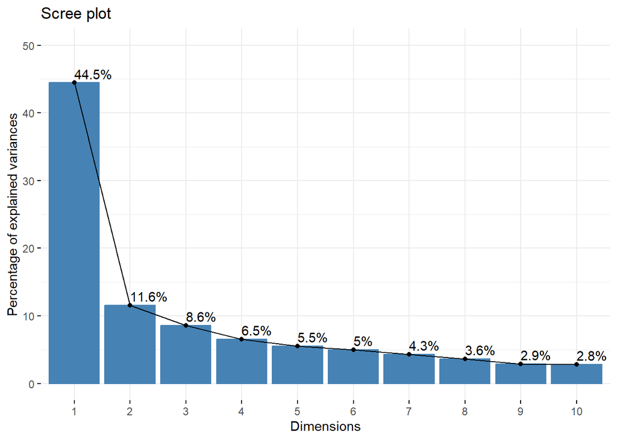

```r
# Scree plot of Variance
fviz_eig(body_pca, addlabels = TRUE, ylim = c(0, 50))
```

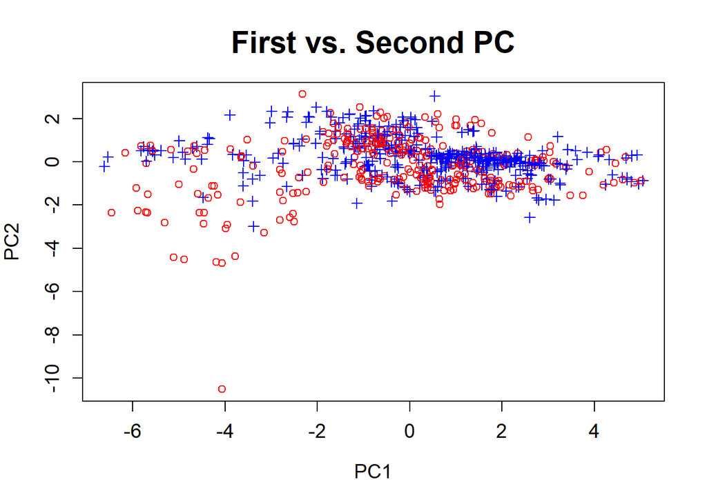

```r
# Define colors based on the first variable
colors <- c(rep("blue", 100), rep("red", 100))  # Adjust as per your actual data


# Plot the first vs. second principal component
plot(x = body_pca$x[, 1], y = body_pca$x[, 2],
     pch = c(rep(3, 100), rep(1, 100)),
     col = c(rep("blue", 100), rep("red", 100)),
     xlab = "PC1", ylab = "PC2", main = "First vs. Second PC",
     cex.lab = 1.2, cex.axis = 1.2, cex.main = 1.8)
```

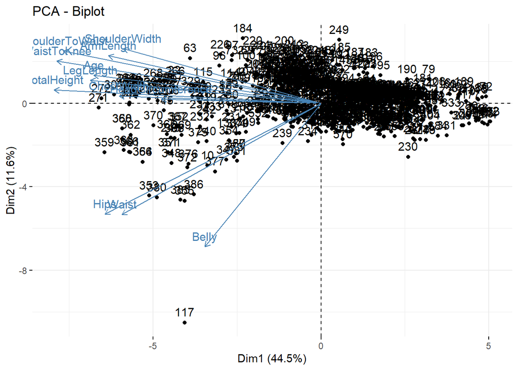

```r
# Biplot with default settings
fviz_pca_biplot(body_pca)
```

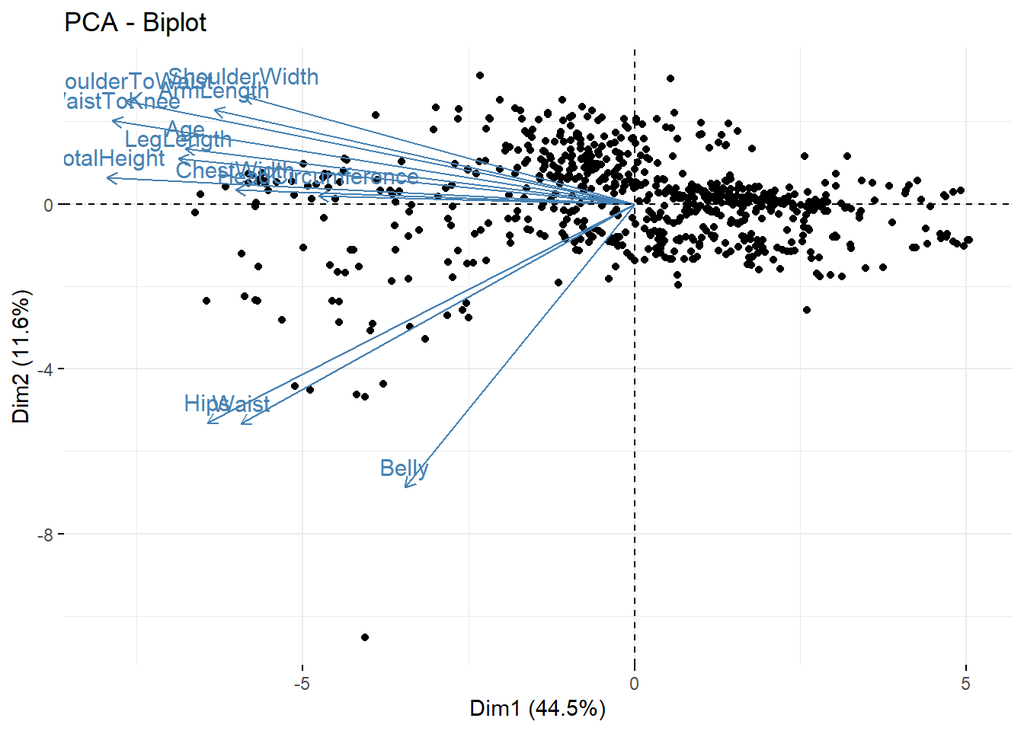

```r
# Biplot with Labeled variables
fviz_pca_biplot(body_pca, label="var")
```

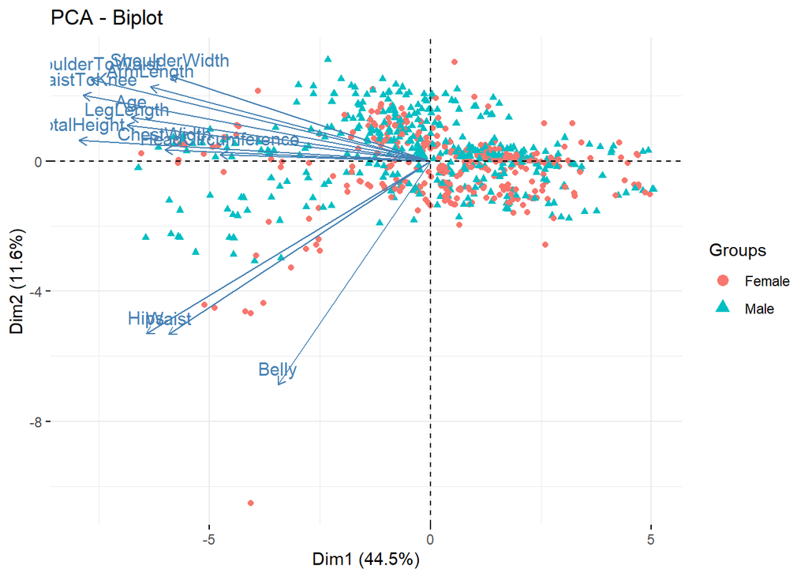

```r
# Biplot with colored groups
fviz_pca_biplot(body_pca, label="var", habillage = body$Gender)
```

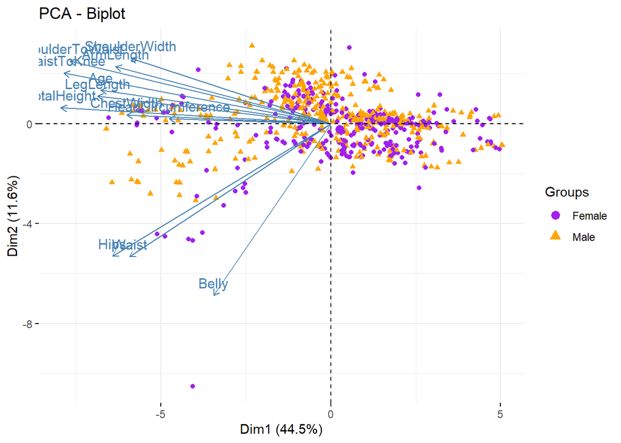

```r
# Biplot with customized Colored Groups and Variables
fviz_pca_biplot(body_pca, label = "var", habillage = body$Gender) +
  scale_color_manual(values = c("Male" = "orange", "Female" = "purple"))
```

[output not shown]